# Risk Factor Analysis

## Outcome Variable

**Outcome Variable:** wasted

## Predictor Variables

**Intervention Variable:** nrooms

**Adjustment Set:**

- arm
- sex
- W_mage
- meducyrs
- feducyrs
- hhwealth_quart
- hfoodsec
- W_mhtcm
- W_nchldlt5
- W_parity
- impfloor
- impsan
- safeh20
- delta_W_mage
- delta_meducyrs
- delta_feducyrs
- delta_hhwealth_quart
- delta_hfoodsec
- delta_W_mhtcm
- delta_W_nchldlt5
- delta_W_parity
- delta_impfloor
- delta_impsan
- delta_safeh20

## Stratifying Variables

The analysis was stratified on these variable(s):

- agecat
- studyid
- country

## Data Summary

| agecat | studyid | country | nrooms | wasted | n_cell | n |
| --- | --- | --- | --- | --- | --- | --- |
| Birth | ki0047075b-MAL-ED | BANGLADESH | 1 | 0 | 106 | 222 |
| Birth | ki0047075b-MAL-ED | BANGLADESH | 1 | 1 | 29 | 222 |
| Birth | ki0047075b-MAL-ED | BANGLADESH | 2 | 0 | 43 | 222 |
| Birth | ki0047075b-MAL-ED | BANGLADESH | 2 | 1 | 4 | 222 |
| Birth | ki0047075b-MAL-ED | BANGLADESH | 3 | 0 | 24 | 222 |
| Birth | ki0047075b-MAL-ED | BANGLADESH | 3 | 1 | 4 | 222 |
| Birth | ki0047075b-MAL-ED | BANGLADESH | 4+ | 0 | 11 | 222 |
| Birth | ki0047075b-MAL-ED | BANGLADESH | 4+ | 1 | 1 | 222 |
| Birth | ki0047075b-MAL-ED | BRAZIL | 1 | 0 | 3 | 167 |
| Birth | ki0047075b-MAL-ED | BRAZIL | 1 | 1 | 0 | 167 |
| Birth | ki0047075b-MAL-ED | BRAZIL | 2 | 0 | 17 | 167 |
| Birth | ki0047075b-MAL-ED | BRAZIL | 2 | 1 | 2 | 167 |
| Birth | ki0047075b-MAL-ED | BRAZIL | 3 | 0 | 46 | 167 |
| Birth | ki0047075b-MAL-ED | BRAZIL | 3 | 1 | 0 | 167 |
| Birth | ki0047075b-MAL-ED | BRAZIL | 4+ | 0 | 95 | 167 |
| Birth | ki0047075b-MAL-ED | BRAZIL | 4+ | 1 | 4 | 167 |
| Birth | ki0047075b-MAL-ED | INDIA | 1 | 0 | 57 | 188 |
| Birth | ki0047075b-MAL-ED | INDIA | 1 | 1 | 11 | 188 |
| Birth | ki0047075b-MAL-ED | INDIA | 2 | 0 | 57 | 188 |
| Birth | ki0047075b-MAL-ED | INDIA | 2 | 1 | 9 | 188 |
| Birth | ki0047075b-MAL-ED | INDIA | 3 | 0 | 25 | 188 |
| Birth | ki0047075b-MAL-ED | INDIA | 3 | 1 | 7 | 188 |
| Birth | ki0047075b-MAL-ED | INDIA | 4+ | 0 | 19 | 188 |
| Birth | ki0047075b-MAL-ED | INDIA | 4+ | 1 | 3 | 188 |
| Birth | ki0047075b-MAL-ED | NEPAL | 1 | 0 | 31 | 166 |
| Birth | ki0047075b-MAL-ED | NEPAL | 1 | 1 | 3 | 166 |
| Birth | ki0047075b-MAL-ED | NEPAL | 2 | 0 | 21 | 166 |
| Birth | ki0047075b-MAL-ED | NEPAL | 2 | 1 | 0 | 166 |
| Birth | ki0047075b-MAL-ED | NEPAL | 3 | 0 | 15 | 166 |
| Birth | ki0047075b-MAL-ED | NEPAL | 3 | 1 | 2 | 166 |

[output cut: 338 more lines]

The following strata were considered:

- agecat: 24 months, studyid: ki0047075b-MAL-ED, country: BANGLADESH
- agecat: 24 months, studyid: ki0047075b-MAL-ED, country: BRAZIL
- agecat: 24 months, studyid: ki0047075b-MAL-ED, country: INDIA
- agecat: 24 months, studyid: ki0047075b-MAL-ED, country: NEPAL
- agecat: 24 months, studyid: ki0047075b-MAL-ED, country: PERU
- agecat: 24 months, studyid: ki0047075b-MAL-ED, country: SOUTH AFRICA
- agecat: 24 months, studyid: ki0047075b-MAL-ED, country: TANZANIA, UNITED REPUBLIC OF
- agecat: 24 months, studyid: ki1000108-CMC-V-BCS-2002, country: INDIA
- agecat: 24 months, studyid: ki1000108-IRC, country: INDIA
- agecat: 24 months, studyid: ki1017093b-PROVIDE, country: BANGLADESH
- agecat: 24 months, studyid: ki1017093c-NIH-Crypto, country: BANGLADESH
- agecat: 24 months, studyid: ki1113344-GMS-Nepal, country: NEPAL
- agecat: 24 months, studyid: ki1114097-CONTENT, country: PERU
- agecat: 24 months, studyid: ki1135781-COHORTS, country: INDIA
- agecat: 24 months, studyid: kiGH5241-JiVitA-3, country: BANGLADESH
- agecat: 24 months, studyid: kiGH5241-JiVitA-4, country: BANGLADESH
- agecat: 6 months, studyid: ki0047075b-MAL-ED, country: BANGLADESH
- agecat: 6 months, studyid: ki0047075b-MAL-ED, country: BRAZIL
- agecat: 6 months, studyid: ki0047075b-MAL-ED, country: INDIA
- agecat: 6 months, studyid: ki0047075b-MAL-ED, country: NEPAL
- agecat: 6 months, studyid: ki0047075b-MAL-ED, country: PERU
- agecat: 6 months, studyid: ki0047075b-MAL-ED, country: SOUTH AFRICA
- agecat: 6 months, studyid: ki0047075b-MAL-ED, country: TANZANIA, UNITED REPUBLIC OF
- agecat: 6 months, studyid: ki1000108-CMC-V-BCS-2002, country: INDIA
- agecat: 6 months, studyid: ki1000108-IRC, country: INDIA
- agecat: 6 months, studyid: ki1017093b-PROVIDE, country: BANGLADESH
- agecat: 6 months, studyid: ki1017093c-NIH-Crypto, country: BANGLADESH
- agecat: 6 months, studyid: ki1113344-GMS-Nepal, country: NEPAL
- agecat: 6 months, studyid: ki1114097-CONTENT, country: PERU
- agecat: 6 months, studyid: ki1135781-COHORTS, country: INDIA
- agecat: 6 months, studyid: kiGH5241-JiVitA-3, country: BANGLADESH
- agecat: 6 months, studyid: kiGH5241-JiVitA-4, country: BANGLADESH
- agecat: Birth, studyid: ki0047075b-MAL-ED, country: BANGLADESH
- agecat: Birth, studyid: ki0047075b-MAL-ED, country: BRAZIL
- agecat: Birth, studyid: ki0047075b-MAL-ED, country: INDIA
- agecat: Birth, studyid: ki0047075b-MAL-ED, country: NEPAL
- agecat: Birth, studyid: ki0047075b-MAL-ED, country: PERU
- agecat: Birth, studyid: ki0047075b-MAL-ED, country: SOUTH AFRICA
- agecat: Birth, studyid: ki0047075b-MAL-ED, country: TANZANIA, UNITED REPUBLIC OF
- agecat: Birth, studyid: ki1000108-CMC-V-BCS-2002, country: INDIA
- agecat: Birth, studyid: ki1000108-IRC, country: INDIA
- agecat: Birth, studyid: ki1017093c-NIH-Crypto, country: BANGLADESH
- agecat: Birth, studyid: ki1114097-CONTENT, country: PERU
- agecat: Birth, studyid: ki1135781-COHORTS, country: INDIA
- agecat: Birth, studyid: kiGH5241-JiVitA-3, country: BANGLADESH
- agecat: Birth, studyid: kiGH5241-JiVitA-4, country: BANGLADESH

### Dropped Strata

Some strata were dropped due to rare outcomes:

- agecat: Birth, studyid: ki0047075b-MAL-ED, country: BANGLADESH
- agecat: Birth, studyid: ki0047075b-MAL-ED, country: BRAZIL
- agecat: Birth, studyid: ki0047075b-MAL-ED, country: INDIA
- agecat: Birth, studyid: ki0047075b-MAL-ED, country: NEPAL
- agecat: Birth, studyid: ki0047075b-MAL-ED, country: PERU
- agecat: Birth, studyid: ki0047075b-MAL-ED, country: SOUTH AFRICA
- agecat: Birth, studyid: ki0047075b-MAL-ED, country: TANZANIA, UNITED REPUBLIC OF
- agecat: Birth, studyid: ki1000108-CMC-V-BCS-2002, country: INDIA
- agecat: Birth, studyid: ki1017093c-NIH-Crypto, country: BANGLADESH
- agecat: Birth, studyid: ki1114097-CONTENT, country: PERU
- agecat: Birth, studyid: kiGH5241-JiVitA-4, country: BANGLADESH
- agecat: 6 months, studyid: ki0047075b-MAL-ED, country: BANGLADESH
- agecat: 6 months, studyid: ki0047075b-MAL-ED, country: BRAZIL
- agecat: 6 months, studyid: ki0047075b-MAL-ED, country: INDIA
- agecat: 6 months, studyid: ki0047075b-MAL-ED, country: NEPAL
- agecat: 6 months, studyid: ki0047075b-MAL-ED, country: PERU
- agecat: 6 months, studyid: ki0047075b-MAL-ED, country: SOUTH AFRICA
- agecat: 6 months, studyid: ki0047075b-MAL-ED, country: TANZANIA, UNITED REPUBLIC OF
- agecat: 6 months, studyid: ki1000108-CMC-V-BCS-2002, country: INDIA
- agecat: 6 months, studyid: ki1000108-IRC, country: INDIA
- agecat: 6 months, studyid: ki1017093b-PROVIDE, country: BANGLADESH
- agecat: 6 months, studyid: ki1017093c-NIH-Crypto, country: BANGLADESH
- agecat: 6 months, studyid: ki1114097-CONTENT, country: PERU
- agecat: 6 months, studyid: ki1135781-COHORTS, country: INDIA
- agecat: 24 months, studyid: ki0047075b-MAL-ED, country: BANGLADESH
- agecat: 24 months, studyid: ki0047075b-MAL-ED, country: BRAZIL
- agecat: 24 months, studyid: ki0047075b-MAL-ED, country: INDIA
- agecat: 24 months, studyid: ki0047075b-MAL-ED, country: NEPAL
- agecat: 24 months, studyid: ki0047075b-MAL-ED, country: PERU
- agecat: 24 months, studyid: ki0047075b-MAL-ED, country: SOUTH AFRICA
- agecat: 24 months, studyid: ki0047075b-MAL-ED, country: TANZANIA, UNITED REPUBLIC OF
- agecat: 24 months, studyid: ki1000108-CMC-V-BCS-2002, country: INDIA
- agecat: 24 months, studyid: ki1000108-IRC, country: INDIA
- agecat: 24 months, studyid: ki1017093b-PROVIDE, country: BANGLADESH
- agecat: 24 months, studyid: ki1017093c-NIH-Crypto, country: BANGLADESH
- agecat: 24 months, studyid: ki1114097-CONTENT, country: PERU
- agecat: 24 months, studyid: ki1135781-COHORTS, country: INDIA

## Methods Detail

We’re interested in the causal parameters $E[Y_a]$ for all values of $a \in \mathcal{A}$. These parameters represent the mean outcome if, possibly contrary to fact, we intervened to set all units to have $A=a$. Under the randomization and positivity assumptions, these are identified by the statistical parameters $\psi_a=E_W[E_{Y|A,W}(Y|A=a,W)]$. In addition, we’re interested in the mean of $Y$, $E[Y]$ under no intervention (the observed mean). We will estimate these parameters by using SuperLearner to fit the relevant likelihood factors – $E_{Y|A,W}(Y|A=a,W)$ and $p(A=a|W)$, and then updating our likelihood fit using a joint TMLE.

For unadjusted analyses ($W=\{\}$), initial likelihoods were estimated using Lrnr_glm to estimate the simple $E(Y|A)$ and Lrnr_mean to estimate $p(A)$. For adjusted analyses, a small library containing Lrnr_glmnet, Lrnr_xgboost, and Lrnr_mean was used.

Having estimated these parameters, we will then use the delta method to estimate relative risks and attributable risks relative to a prespecified baseline level of $A$.

# Results Detail

## Results Plots

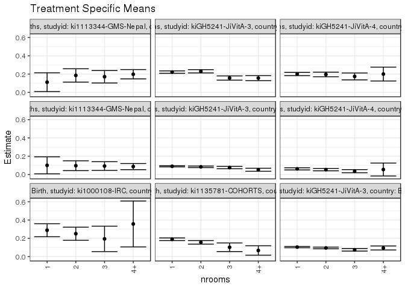

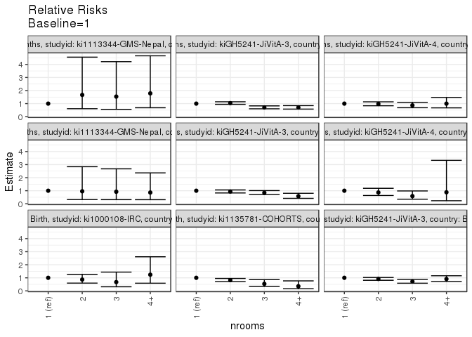

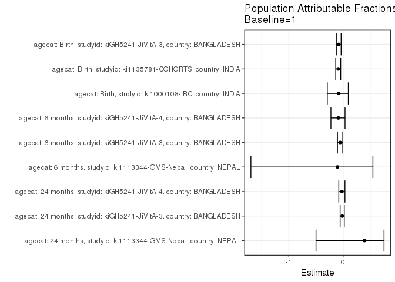

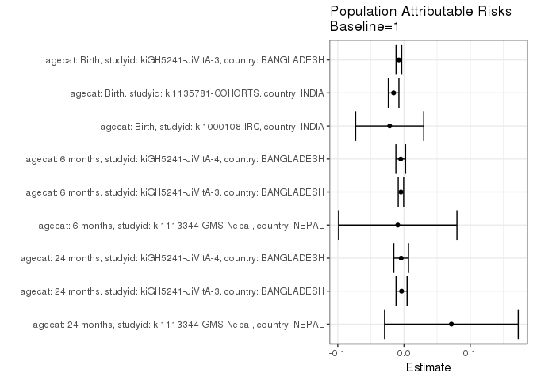

## Results Table

### Parameter: TSM

| agecat | studyid | country | intervention_level | baseline_level | estimate | ci_lower | ci_upper |
| --- | --- | --- | --- | --- | --- | --- | --- |
| Birth | ki1000108-IRC | INDIA | 1 | NA | 0.2884615 | 0.2172637 | 0.3596594 |
| Birth | ki1000108-IRC | INDIA | 2 | NA | 0.2500000 | 0.1781673 | 0.3218327 |
| Birth | ki1000108-IRC | INDIA | 3 | NA | 0.1935484 | 0.0542683 | 0.3328284 |
| Birth | ki1000108-IRC | INDIA | 4+ | NA | 0.3571429 | 0.1057806 | 0.6085051 |
| Birth | ki1135781-COHORTS | INDIA | 1 | NA | 0.1896492 | 0.1753277 | 0.2039707 |
| Birth | ki1135781-COHORTS | INDIA | 2 | NA | 0.1558735 | 0.1363621 | 0.1753849 |
| Birth | ki1135781-COHORTS | INDIA | 3 | NA | 0.1019108 | 0.0545830 | 0.1492387 |
| Birth | ki1135781-COHORTS | INDIA | 4+ | NA | 0.0666667 | 0.0151262 | 0.1182071 |
| Birth | kiGH5241-JiVitA-3 | BANGLADESH | 1 | NA | 0.1036633 | 0.0966503 | 0.1106763 |
| Birth | kiGH5241-JiVitA-3 | BANGLADESH | 2 | NA | 0.0945347 | 0.0853775 | 0.1036919 |
| Birth | kiGH5241-JiVitA-3 | BANGLADESH | 3 | NA | 0.0741634 | 0.0603095 | 0.0880172 |
| Birth | kiGH5241-JiVitA-3 | BANGLADESH | 4+ | NA | 0.0942482 | 0.0724903 | 0.1160061 |
| 6 months | ki1113344-GMS-Nepal | NEPAL | 1 | NA | 0.1000000 | 0.0069481 | 0.1930519 |
| 6 months | ki1113344-GMS-Nepal | NEPAL | 2 | NA | 0.0956522 | 0.0418499 | 0.1494544 |
| 6 months | ki1113344-GMS-Nepal | NEPAL | 3 | NA | 0.0921986 | 0.0444036 | 0.1399935 |
| 6 months | ki1113344-GMS-Nepal | NEPAL | 4+ | NA | 0.0861423 | 0.0524581 | 0.1198265 |
| 6 months | kiGH5241-JiVitA-3 | BANGLADESH | 1 | NA | 0.0891725 | 0.0830421 | 0.0953029 |
| 6 months | kiGH5241-JiVitA-3 | BANGLADESH | 2 | NA | 0.0835419 | 0.0748888 | 0.0921950 |
| 6 months | kiGH5241-JiVitA-3 | BANGLADESH | 3 | NA | 0.0751531 | 0.0622705 | 0.0880357 |
| 6 months | kiGH5241-JiVitA-3 | BANGLADESH | 4+ | NA | 0.0514530 | 0.0349819 | 0.0679242 |
| 6 months | kiGH5241-JiVitA-4 | BANGLADESH | 1 | NA | 0.0612455 | 0.0493070 | 0.0731840 |
| 6 months | kiGH5241-JiVitA-4 | BANGLADESH | 2 | NA | 0.0530732 | 0.0401431 | 0.0660032 |
| 6 months | kiGH5241-JiVitA-4 | BANGLADESH | 3 | NA | 0.0359703 | 0.0188356 | 0.0531050 |
| 6 months | kiGH5241-JiVitA-4 | BANGLADESH | 4+ | NA | 0.0539294 | -0.0169751 | 0.1248338 |
| 24 months | ki1113344-GMS-Nepal | NEPAL | 1 | NA | 0.1111111 | 0.0083483 | 0.2138739 |
| 24 months | ki1113344-GMS-Nepal | NEPAL | 2 | NA | 0.1851852 | 0.1118512 | 0.2585192 |
| 24 months | ki1113344-GMS-Nepal | NEPAL | 3 | NA | 0.1709402 | 0.1026581 | 0.2392222 |
| 24 months | ki1113344-GMS-Nepal | NEPAL | 4+ | NA | 0.1983122 | 0.1474977 | 0.2491268 |
| 24 months | kiGH5241-JiVitA-3 | BANGLADESH | 1 | NA | 0.2217760 | 0.2090024 | 0.2345495 |
| 24 months | kiGH5241-JiVitA-3 | BANGLADESH | 2 | NA | 0.2303426 | 0.2124684 | 0.2482168 |
| 24 months | kiGH5241-JiVitA-3 | BANGLADESH | 3 | NA | 0.1567340 | 0.1337384 | 0.1797295 |
| 24 months | kiGH5241-JiVitA-3 | BANGLADESH | 4+ | NA | 0.1557689 | 0.1281814 | 0.1833565 |
| 24 months | kiGH5241-JiVitA-4 | BANGLADESH | 1 | NA | 0.2006594 | 0.1830778 | 0.2182410 |
| 24 months | kiGH5241-JiVitA-4 | BANGLADESH | 2 | NA | 0.1956879 | 0.1705148 | 0.2208609 |
| 24 months | kiGH5241-JiVitA-4 | BANGLADESH | 3 | NA | 0.1742172 | 0.1365144 | 0.2119200 |
| 24 months | kiGH5241-JiVitA-4 | BANGLADESH | 4+ | NA | 0.2001100 | 0.1241269 | 0.2760932 |

### Parameter: E(Y)

| agecat | studyid | country | intervention_level | baseline_level | estimate | ci_lower | ci_upper |
| --- | --- | --- | --- | --- | --- | --- | --- |
| Birth | ki1000108-IRC | INDIA | NA | NA | 0.2668622 | 0.2198462 | 0.3138781 |
| Birth | ki1135781-COHORTS | INDIA | NA | NA | 0.1740009 | 0.1628660 | 0.1851358 |
| Birth | kiGH5241-JiVitA-3 | BANGLADESH | NA | NA | 0.0959454 | 0.0907405 | 0.1011503 |
| 6 months | ki1113344-GMS-Nepal | NEPAL | NA | NA | 0.0905861 | 0.0668565 | 0.1143158 |
| 6 months | kiGH5241-JiVitA-3 | BANGLADESH | NA | NA | 0.0845646 | 0.0797577 | 0.0893716 |
| 6 months | kiGH5241-JiVitA-4 | BANGLADESH | NA | NA | 0.0563261 | 0.0473846 | 0.0652676 |
| 24 months | ki1113344-GMS-Nepal | NEPAL | NA | NA | 0.1827309 | 0.1487560 | 0.2167058 |
| 24 months | kiGH5241-JiVitA-3 | BANGLADESH | NA | NA | 0.2181521 | 0.2082397 | 0.2280645 |
| 24 months | kiGH5241-JiVitA-4 | BANGLADESH | NA | NA | 0.1963841 | 0.1829372 | 0.2098310 |

### Parameter: RR

| agecat | studyid | country | intervention_level | baseline_level | estimate | ci_lower | ci_upper |
| --- | --- | --- | --- | --- | --- | --- | --- |
| Birth | ki1000108-IRC | INDIA | 1 | 1 | 1.0000000 | 1.0000000 | 1.0000000 |
| Birth | ki1000108-IRC | INDIA | 2 | 1 | 0.8666667 | 0.5933999 | 1.2657756 |
| Birth | ki1000108-IRC | INDIA | 3 | 1 | 0.6709677 | 0.3135491 | 1.4358123 |
| Birth | ki1000108-IRC | INDIA | 4+ | 1 | 1.2380952 | 0.5872740 | 2.6101612 |
| Birth | ki1135781-COHORTS | INDIA | 1 | 1 | 1.0000000 | 1.0000000 | 1.0000000 |
| Birth | ki1135781-COHORTS | INDIA | 2 | 1 | 0.8219044 | 0.7101207 | 0.9512844 |
| Birth | ki1135781-COHORTS | INDIA | 3 | 1 | 0.5373650 | 0.3356850 | 0.8602146 |
| Birth | ki1135781-COHORTS | INDIA | 4+ | 1 | 0.3515263 | 0.1616604 | 0.7643844 |
| Birth | kiGH5241-JiVitA-3 | BANGLADESH | 1 | 1 | 1.0000000 | 1.0000000 | 1.0000000 |
| Birth | kiGH5241-JiVitA-3 | BANGLADESH | 2 | 1 | 0.9119400 | 0.8110849 | 1.0253360 |
| Birth | kiGH5241-JiVitA-3 | BANGLADESH | 3 | 1 | 0.7154253 | 0.5864880 | 0.8727090 |
| Birth | kiGH5241-JiVitA-3 | BANGLADESH | 4+ | 1 | 0.9091765 | 0.7149680 | 1.1561382 |
| 6 months | ki1113344-GMS-Nepal | NEPAL | 1 | 1 | 1.0000000 | 1.0000000 | 1.0000000 |
| 6 months | ki1113344-GMS-Nepal | NEPAL | 2 | 1 | 0.9565217 | 0.3224640 | 2.8373212 |
| 6 months | ki1113344-GMS-Nepal | NEPAL | 3 | 1 | 0.9219858 | 0.3177788 | 2.6749982 |
| 6 months | ki1113344-GMS-Nepal | NEPAL | 4+ | 1 | 0.8614232 | 0.3139534 | 2.3635675 |
| 6 months | kiGH5241-JiVitA-3 | BANGLADESH | 1 | 1 | 1.0000000 | 1.0000000 | 1.0000000 |
| 6 months | kiGH5241-JiVitA-3 | BANGLADESH | 2 | 1 | 0.9368576 | 0.8288212 | 1.0589766 |
| 6 months | kiGH5241-JiVitA-3 | BANGLADESH | 3 | 1 | 0.8427832 | 0.7021140 | 1.0116357 |
| 6 months | kiGH5241-JiVitA-3 | BANGLADESH | 4+ | 1 | 0.5770057 | 0.4145692 | 0.8030880 |
| 6 months | kiGH5241-JiVitA-4 | BANGLADESH | 1 | 1 | 1.0000000 | 1.0000000 | 1.0000000 |
| 6 months | kiGH5241-JiVitA-4 | BANGLADESH | 2 | 1 | 0.8665641 | 0.6339181 | 1.1845904 |
| 6 months | kiGH5241-JiVitA-4 | BANGLADESH | 3 | 1 | 0.5873128 | 0.3515273 | 0.9812505 |
| 6 months | kiGH5241-JiVitA-4 | BANGLADESH | 4+ | 1 | 0.8805439 | 0.2331435 | 3.3256673 |
| 24 months | ki1113344-GMS-Nepal | NEPAL | 1 | 1 | 1.0000000 | 1.0000000 | 1.0000000 |
| 24 months | ki1113344-GMS-Nepal | NEPAL | 2 | 1 | 1.6666667 | 0.6094168 | 4.5580919 |
| 24 months | ki1113344-GMS-Nepal | NEPAL | 3 | 1 | 1.5384615 | 0.5617732 | 4.2132022 |
| 24 months | ki1113344-GMS-Nepal | NEPAL | 4+ | 1 | 1.7848101 | 0.6835935 | 4.6600020 |
| 24 months | kiGH5241-JiVitA-3 | BANGLADESH | 1 | 1 | 1.0000000 | 1.0000000 | 1.0000000 |
| 24 months | kiGH5241-JiVitA-3 | BANGLADESH | 2 | 1 | 1.0386275 | 0.9450521 | 1.1414684 |
| 24 months | kiGH5241-JiVitA-3 | BANGLADESH | 3 | 1 | 0.7067220 | 0.6033645 | 0.8277849 |
| 24 months | kiGH5241-JiVitA-3 | BANGLADESH | 4+ | 1 | 0.7023707 | 0.5826386 | 0.8467078 |
| 24 months | kiGH5241-JiVitA-4 | BANGLADESH | 1 | 1 | 1.0000000 | 1.0000000 | 1.0000000 |
| 24 months | kiGH5241-JiVitA-4 | BANGLADESH | 2 | 1 | 0.9752239 | 0.8364995 | 1.1369544 |
| 24 months | kiGH5241-JiVitA-4 | BANGLADESH | 3 | 1 | 0.8682234 | 0.6866092 | 1.0978761 |
| 24 months | kiGH5241-JiVitA-4 | BANGLADESH | 4+ | 1 | 0.9972621 | 0.6744773 | 1.4745221 |

### Parameter: PAR

| agecat | studyid | country | intervention_level | baseline_level | estimate | ci_lower | ci_upper |
| --- | --- | --- | --- | --- | --- | --- | --- |
| Birth | ki1000108-IRC | INDIA | 1 | NA | -0.0215994 | -0.0729958 | 0.0297971 |
| Birth | ki1135781-COHORTS | INDIA | 1 | NA | -0.0156483 | -0.0236444 | -0.0076522 |
| Birth | kiGH5241-JiVitA-3 | BANGLADESH | 1 | NA | -0.0077179 | -0.0119620 | -0.0034737 |
| 6 months | ki1113344-GMS-Nepal | NEPAL | 1 | NA | -0.0094139 | -0.0988085 | 0.0799808 |
| 6 months | kiGH5241-JiVitA-3 | BANGLADESH | 1 | NA | -0.0046078 | -0.0086982 | -0.0005175 |
| 6 months | kiGH5241-JiVitA-4 | BANGLADESH | 1 | NA | -0.0049194 | -0.0122368 | 0.0023980 |
| 24 months | ki1113344-GMS-Nepal | NEPAL | 1 | NA | 0.0716198 | -0.0293144 | 0.1725540 |
| 24 months | kiGH5241-JiVitA-3 | BANGLADESH | 1 | NA | -0.0036238 | -0.0119553 | 0.0047076 |
| 24 months | kiGH5241-JiVitA-4 | BANGLADESH | 1 | NA | -0.0042753 | -0.0153770 | 0.0068264 |

### Parameter: PAF

| agecat | studyid | country | intervention_level | baseline_level | estimate | ci_lower | ci_upper |
| --- | --- | --- | --- | --- | --- | --- | --- |
| Birth | ki1000108-IRC | INDIA | 1 | NA | -0.0809383 | -0.2916232 | 0.0953805 |
| Birth | ki1135781-COHORTS | INDIA | 1 | NA | -0.0899322 | -0.1366655 | -0.0451203 |
| Birth | kiGH5241-JiVitA-3 | BANGLADESH | 1 | NA | -0.0804402 | -0.1253974 | -0.0372790 |
| 6 months | ki1113344-GMS-Nepal | NEPAL | 1 | NA | -0.1039216 | -1.6981052 | 0.5483338 |
| 6 months | kiGH5241-JiVitA-3 | BANGLADESH | 1 | NA | -0.0544891 | -0.1042739 | -0.0069487 |
| 6 months | kiGH5241-JiVitA-4 | BANGLADESH | 1 | NA | -0.0873380 | -0.2250829 | 0.0349192 |
| 24 months | ki1113344-GMS-Nepal | NEPAL | 1 | NA | 0.3919414 | -0.4995263 | 0.7534320 |
| 24 months | kiGH5241-JiVitA-3 | BANGLADESH | 1 | NA | -0.0166115 | -0.0555580 | 0.0208980 |
| 24 months | kiGH5241-JiVitA-4 | BANGLADESH | 1 | NA | -0.0217701 | -0.0798879 | 0.0332199 |